# Cluster Analysis

WDI Indicators

94101448

2018-07-14 00:49:38

> با توجه به داده بانک جهانی به سوالات زیر پاسخ دهید. برای استفاده از داده از سه فایل زیر استفاده نمایید. داده نام کشورها: WDICountry داده نام سری های زمانی: WDISeries داده کل: WDIData در صورتی که داده را در اختیار ندارید می توانید از بسته WDI استفاده نموده و داده های مورد نظر را استخراج نمایید.

```r
library(dplyr)
```

```r
library(highcharter)
library(ggplot2)
library(tidyr)
library(stringr)
library(tidytext)
```

۱. ده کشور فقیر دنیا را بیابید. نمودار درآمد روزانه آنها را رسم کنید. چند درصد از اعضای این کشورها زیر خط فقر هستند؟ متوسط عمر در این کشورها چقدر است؟

```r
library(readxl)
indicator_life_expectancy_at_birth <-
  read_excel("/Users/macbook/Downloads/indicator life_expectancy_at_birth.xlsx")

indicatorGNIpercapitaPPP <-
  read_excel("/Users/macbook/Documents/university/term6/data analysis/HW/hw_10/indicatorGNIpercapitaPPP.xlsx")

poverty<- read_excel("/Users/macbook/Downloads/indicator SI_POV_NAHC.xls-2.xlsx")
#indicatorGNIpercapitaPPP:  gross national income data for each country up to 2011-sorce:gapminder
income=indicatorGNIpercapitaPPP %>% select(country=c(1),c(48:52)) %>%
  mutate(country=country,income_ind=(`2011`+`2010`+`2009`+`2008`+`2007`)/5) %>%
  mutate(rank=rank(income_ind)) %>% filter(rank<11)

#we devide average annual income by 365 to obtain average daily income
#and we plot the barplot
library(highcharter)
income %>% hchart("column",hcaes(x=country,y=income_ind/365))
```

[interactive chart not shown]

```r
poor_country=income$country

#indicator_life_expectancy_at_birth:life expectancy data-sorce:gapminder
lifeexp=indicator_life_expectancy_at_birth %>% filter(`Life expectancy` %in% poor_country) %>%
  select(c(1),c(214:218)) %>% mutate(avg_life_exp=(`2012.0`+`2013.0`+`2014.0`+`2015.0`+`2016.0`)/5)

lifeexp %>% hchart("column",hcaes(x=`Life expectancy`,y=avg_life_exp))
```

[interactive chart not shown]

```r
# poverty line data: sorce:gap minder
poverty=poverty %>%
  filter(poverty$`Poverty headcount ratio at national poverty line (% of population)` %in% poor_country)

  poverty=poverty %>% mutate(country=poverty$`Poverty headcount ratio at national poverty line (% of population)`)%>%           mutate(mean_pov=rowMeans(poverty[,c(2:31)], na.rm = TRUE, dims = 1))

poverty$mean_pov
```

```
## [1] 52.21   NaN 53.00 44.85   NaN 59.65 61.75 63.00 76.50
```

```r
poverty %>% hchart("column",hcaes(x=country,y=mean_pov))
```

[interactive chart not shown]

۲. تراژدی روآندا: بر اساس داده های امید به زندگی ابتدا نمودار سالانه نمودار جعبه ایی امید به زندگی کشورها را رسم نمایید(در یک نمودار!). سپس سری زمانی امید به زندگی روآندا را به آن اضافه کنید. چه می بینید؟ چند میلیون نفر کشته شدند؟

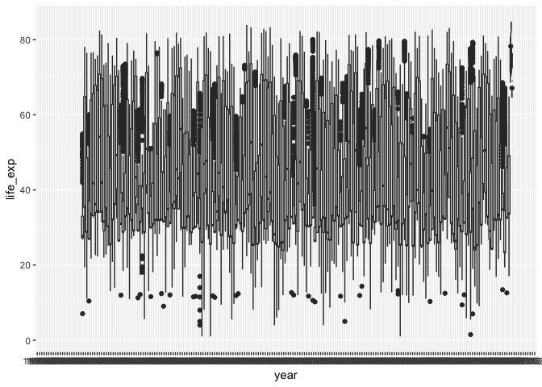

```r
data=indicator_life_expectancy_at_birth %>% gather('year','life_exp',2:218)
ggplot(data,aes(x=year,y=life_exp,group=`Life expectancy`))+geom_boxplot()
```

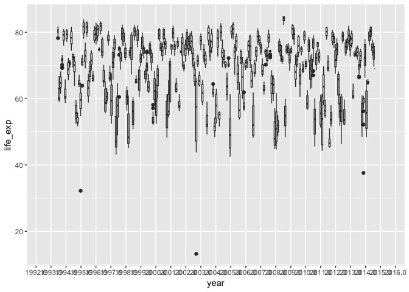

```r
# binahayat shulugh!
#pas baraye sal haye akhir ra rasm mikonim
ggplot(data[c(50000:56420),],aes(x=year,y=life_exp,group=`Life expectancy`))+geom_boxplot()
```

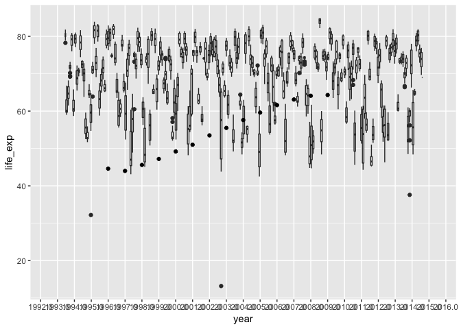

```r
#ba jitter kheili shulugh mishe
#ggplot(data[c(50000:56420),],aes(x=year,y=life_exp,group=`Life expectancy`))+geom_boxplot()+geom_jitter()

rwanda_ser=indicator_life_expectancy_at_birth %>% filter(`Life expectancy`=='Rwanda') %>%
  gather('year','life_exp',2:218)

ggplot()+geom_boxplot(data=data[c(50000:56420),],aes(x=year,y=life_exp,group=`Life expectancy`))+
geom_point(data=rwanda_ser[c(197:210),],aes(x=year,y=life_exp))
```

```r
#در حوالی سال ۱۹۹۴ طول عمر به حدود ۱۰ سال رسیده که متناظر با تراژدی رواندا در سال ۱۹۹۴ است
#در سال ۱۹۹۴ تعداد زیادی از مردم رواندا در کشتازی حمعی غلیه توتسی ها کشته شدند
```

۳. نمودار امید به زندگی و هزینه های بهداشتی را رسم کنید. چه نتیجه ایی می گیرید؟

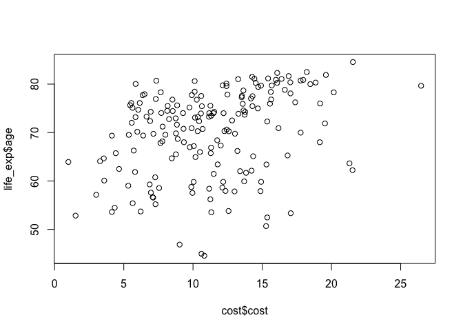

```r
library(readxl)
indicator_government_health_spending_of_total_gov_spending_2 <- read_excel("/Users/macbook/Downloads/indicator_government health spending of total gov spending (%)-2.xlsx")

cost=indicator_government_health_spending_of_total_gov_spending_2 %>% select(c(1),c(13:17)) %>%
  mutate(cost=(`2006.0`+`2007.0`+`2008.0`+`2009.0`+`2010.0`)/5)

life_exp=indicator_life_expectancy_at_birth %>% select(c(1),c(208:212)) %>%
  mutate(age=(`2006.0`+`2007.0`+`2008.0`+`2009.0`+`2010.0`)/5)

cost=cost %>% filter(`General government expenditure on health as percentage of total government expenditure` %in% life_exp$`Life expectancy`)

#we have plot average cost's and life expectancy over years for diffrent countries
plot(x=cost$cost,y=life_exp$age)
```

```r
# we can colclude that countries who spent more on health equipments have higher life expectancy
```

۴. آیا قدرت خرید خانواده های ایرانی در ۵۰ سال اخیر افزایش یافته است؟ برای این کار از داده های اقتصادی خانوار استفاده کنید.

```
## geom_path: Each group consists of only one observation. Do you need to
## adjust the group aesthetic?
```

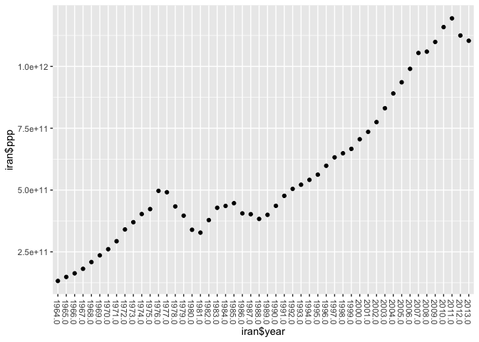

```r
#gdp bayan gar e ghodrat e kharid ast
#sootoon 104 data indicator gapminder gdp per capital(ppp)
library(readxl)
indicator_gdp_total_ppp<- read_excel("/Users/macbook/Downloads/indicator gdp_total_ppp.xlsx")

iran=indicator_gdp_total_ppp[104,c(166:215)]
iran=iran %>% gather(year,ppp)

ggplot(iran) +geom_point(aes(x=iran$year,y=iran$ppp))+geom_line(aes(x=iran$year,y=iran$ppp))+
  theme(axis.text.x = element_text(angle = -90,vjust = 0.65))
```

```r
#trend in general:up
#bale mitavan goft k ghodrat e kharid afzayesh peida karde(ba tavajoh be data gdp ma)
```

۵. رشد اقتصادی ایران را با کشورهای دیگر در طول ۲۰ سال گذشته بر حسب بیست شاخص های اقتصادی مهم مانند تولید ناخالص ملی، تورم و … ارزیابی کنید! (برای هر شاخص از تصویرسازی استفاده کنید.)

```r
library(readr)
WDIData <- read_csv("/Users/macbook/Documents/university/term6/data analysis/HW/hw_10/WDI_csv/WDIData.csv")
WDISeries <- read_csv("/Users/macbook/Documents/university/term6/data analysis/HW/hw_10/WDI_csv/WDISeries.csv")
```

```r
data=bind_cols(WDIData[,1:3],WDIData[,43:62])
series=WDISeries[c(1:3)]
data_merged=merge(data,series)
#baraye inke nemudar kheili shulugh nashe chand ta keshvar entekhab shode
countrylist=c('Iran, Islamic Rep.','Germany','France','Russian Federation')
final=data_merged %>% filter((str_detect(Topic,'Economic') & str_detect(Topic,'Policy'))==TRUE) %>%
  filter(`Country Name`%in% countrylist)

final=final %>%
  group_by(`Country Name`) %>%
  select(-`Country Code`,-Topic,-`Series Code`)

final= gather(final,key="year",value="val",3:22)
final=final %>% arrange(final$`Indicator Name`)
indicator=final[,1] %>% distinct()

for (i in c(1:20)) {
final$check=(final$`Indicator Name`==indicator$`Indicator Name`[i])
temp=final %>% filter(check==TRUE)
temp=temp %>% arrange(year)
hc<-temp %>% hchart("line",hcaes(x=year,y=val,group=`Country Name`))
print(hc)
}
```

۶. در قسمت قبل با استفاده از روش خوشه بندی k-means داده ها را به سه دسته تقسیم کنید. ایران در کدام دسته می گنجد؟ (پیش از خوشه بندی طبیعتا داده را باید پاکسازی و استاندارد سازی نمایید.)

```r
#miangin 20 meyar ra be onvan e roshd e eghtesadi dar nazar migirim

data=bind_cols(WDIData[,1:3],WDIData[,43:62])
series=WDISeries[c(1:3)]
data_merged=merge(data,series)
final=data_merged %>% filter((str_detect(Topic,'Economic') & str_detect(Topic,'Policy'))==TRUE)

final=final %>%
  group_by(`Country Name`) %>%
  select(-`Country Code`,-Topic,-`Series Code`)

indicator=final[,1] %>% distinct()

for (i in c(1)) {
final$check=(final$`Indicator Name`==indicator$`Indicator Name`[i])
temp=final %>% filter(check==TRUE)
listdata=list(temp)
}


for (i in c(2:20)) {
final$check=(final$`Indicator Name`==indicator$`Indicator Name`[i])
temp=final %>% filter(check==TRUE)
listdata[[i]]=temp
}

test=listdata[[1]]
#normalize
test[,c(3:22)]=scale(test[,c(3:22)])
#remove NA
test[is.na(test)]<-0

for (i in c(2:20)){
test2=listdata[[i]]
test2[,c(3:22)]=scale(test2[,c(3:22)])
#remove NA
test2[is.na(test2)]<-0
test[,c(3:22)]=test[,c(3:22)]+test2[,c(3:22)]
}

kcl=kmeans(test[,c(3:22)],centers = 3)
print('Iran is in group:')
```

```
## [1] "Iran is in group:"
```

```r
kcl$cluster[210]
```

```
## [1] 2
```

۷. به وسیله تحلیل مولفه اصلی بعد داده رو به دو کاهش دهید سپس خوشه های به دست آمده در قسمت قبل را بر روی آن نمایش دهید. آیا عملکرد روش خوشه بندی شما مطلوب بوده است؟

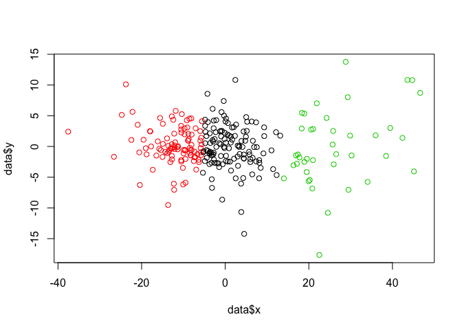

```r
test$label=kcl$cluster
pca = prcomp(test[,c(3:22)])
data=data.frame(x=pca$x[,1],y=pca$x[,2],color=kcl$cluster)
plot(data$x,data$y,col=data$color)
```

۸. با استفاده از داده روشی برای پیش بینی رشد اقتصادی ایران در سال آینده ارائه دهید.

```r
data=bind_cols(WDIData[,1:3],WDIData[,43:62])
series=WDISeries[c(1:3)]
data_merged=merge(data,series)
final=data_merged %>% filter((str_detect(Topic,'Economic') & str_detect(Topic,'Policy'))==TRUE)

final=final %>%
  group_by(`Country Name`) %>%
  select(-`Country Code`,-Topic,-`Series Code`)

final=final %>% filter(`Country Name`=='Iran, Islamic Rep.')
# bar asa 19 sal ghabl predict mikone
colnames(final)=c('Indicator Name','Country Name','1','2','3','4','5','6','7','8','9','10','11','12','13','14','15','16','17','18','19','20')
col=colnames(final)
fit = lm(`19` ~`18`+`17`+`16`+`15`+`14`+`13`+`12`+`11`+`10`+`9`+`8`, data = final)
summary(fit)
```

```
##
## Call:
## lm(formula = `19` ~ `18` + `17` + `16` + `15` + `14` + `13` +
##     `12` + `11` + `10` + `9` + `8`, data = final)
##
## Residuals:
##        Min         1Q     Median         3Q        Max
## -2.225e+14  9.374e+11  9.374e+11  9.374e+11  1.766e+14
##
## Coefficients:
##               Estimate Std. Error t value Pr(>|t|)
## (Intercept) -9.374e+11  1.780e+12  -0.527 0.598780
## `18`         6.706e-01  3.491e-02  19.210  < 2e-16 ***
## `17`         8.029e-01  7.504e-02  10.699  < 2e-16 ***
## `16`        -3.358e-02  8.803e-02  -0.381 0.703061
## `15`        -2.778e-01  1.170e-01  -2.373 0.018106 *
## `14`        -3.123e-01  8.530e-02  -3.661 0.000286 ***
## `13`         2.603e+00  1.512e-01  17.214  < 2e-16 ***
## `12`        -1.577e+00  2.616e-01  -6.029 3.84e-09 ***
## `11`        -1.549e+00  2.306e-01  -6.718 6.57e-11 ***
## `10`        -1.638e+00  1.473e-01 -11.118  < 2e-16 ***
## `9`          2.398e-01  3.333e-01   0.720 0.472179
## `8`          2.347e+00  3.364e-01   6.978 1.29e-11 ***
## ---
## Signif. codes:  0 '***' 0.001 '**' 0.01 '*' 0.05 '.' 0.1 ' ' 1
##
## Residual standard error: 3.434e+13 on 389 degrees of freedom
##   (106 observations deleted due to missingness)
## Multiple R-squared:  0.9996, Adjusted R-squared:  0.9996
## F-statistic: 9.59e+04 on 11 and 389 DF,  p-value: < 2.2e-16
```

```r
#make the test data
test=final
colnames(test)=c('Indicator Name','Country Name','none','1','2','3','4','5','6','7','8','9','10','11','12','13','14','15','16','17','18','19')

predicted=predict(fit,test)
```

۹. سوالهای ۵ تا ۷ را ابتدا برای ۲۰ شاخص سلامت سپس بر حسب ۲۰ شاخص آموزشی تکرار کنید.

```r
#health:data is incomplete
data=bind_cols(WDIData[,1:3],WDIData[,43:62])
series=WDISeries[c(1:3)]
data_merged=merge(data,series)

countrylist=c('Iran, Islamic Rep.','Germany','France','Russian Federation')
final=data_merged %>% filter((str_detect(Topic,'Health')))  %>%
  filter(`Country Name`%in% countrylist)

final=final %>%
  group_by(`Country Name`) %>%
  select(-`Country Code`,-Topic,-`Series Code`)

final= gather(final,key="year",value="val",3:22)
final=final %>% arrange(final$`Indicator Name`)
indicator=final[,1] %>% distinct()

for (i in c(1:20)) {
final$check=(final$`Indicator Name`==indicator$`Indicator Name`[i])
temp=final %>% filter(check==TRUE)
temp=temp %>% arrange(year)
hc<-temp %>% hchart("line",hcaes(x=year,y=val,group=`Country Name`))
print(hc)
}
```

```r
#edu
data=bind_cols(WDIData[,1:3],WDIData[,43:62])
series=WDISeries[c(1:3)]
data_merged=merge(data,series)

countrylist=c('Iran, Islamic Rep.','Germany','France','Russian Federation')
final=data_merged %>%  filter((str_detect(Topic,'Education')))   %>%
  filter(`Country Name`%in% countrylist)

final=final %>%
  group_by(`Country Name`) %>%
  select(-`Country Code`,-Topic,-`Series Code`)

final= gather(final,key="year",value="val",3:22)
final=final %>% arrange(final$`Indicator Name`)
indicator=final[,1] %>% distinct()

for (i in c(1:20)) {
final$check=(final$`Indicator Name`==indicator$`Indicator Name`[i])
temp=final %>% filter(check==TRUE)
temp=temp %>% arrange(year)
hc<-temp %>% hchart("line",hcaes(x=year,y=val,group=`Country Name`))
print(hc)
}
```

۱۰. کشورهای دنیا را بر حسب ۶۰ شاخص اقتصادی، سلامت و آموزش با روش سلسله مراتبی خوشه بندی کرده و دندروگرام آن را رسم نمایید. اگر داده ها بر سه دسته تقسیم شوند ایران در کدام دسته می گنجد؟

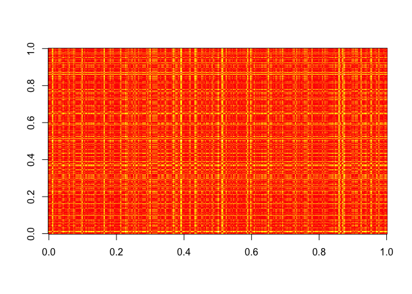

```r
data=bind_cols(WDIData[,1:3],WDIData[,43:62])
series=WDISeries[c(1:3)]
data_merged=merge(data,series)
final=data_merged %>%
  filter(((str_detect(Topic,'Economic') & str_detect(Topic,'Policy')) | ((str_detect(Topic,'Education')))
          |((str_detect(Topic,'Health'))))==TRUE)

final=final %>%
  group_by(`Country Name`) %>%
  select(-`Country Code`,-Topic,-`Series Code`)

indicator=final[,1] %>% distinct()

for (i in c(1)) {
final$check=(final$`Indicator Name`==indicator$`Indicator Name`[i])
temp=final %>% filter(check==TRUE)
listdata=list(temp)
}


for (i in c(2:60)) {
final$check=(final$`Indicator Name`==indicator$`Indicator Name`[i])
temp=final %>% filter(check==TRUE)
listdata[[i]]=temp
}

test=listdata[[1]]
#normalize
test[,c(3:22)]=scale(test[,c(3:22)])
#remove NA
test[is.na(test)]<-0

for (i in c(2:60)){
test2=listdata[[i]]
test2[,c(3:22)]=scale(test2[,c(3:22)])
#remove NA
test2[is.na(test2)]<-0
test[,c(3:22)]=test[,c(3:22)]+test2[,c(3:22)]
}

#clstering
dist = stats::dist(test,method = "euclidean")
dist %>% as.matrix() %>% image()
```

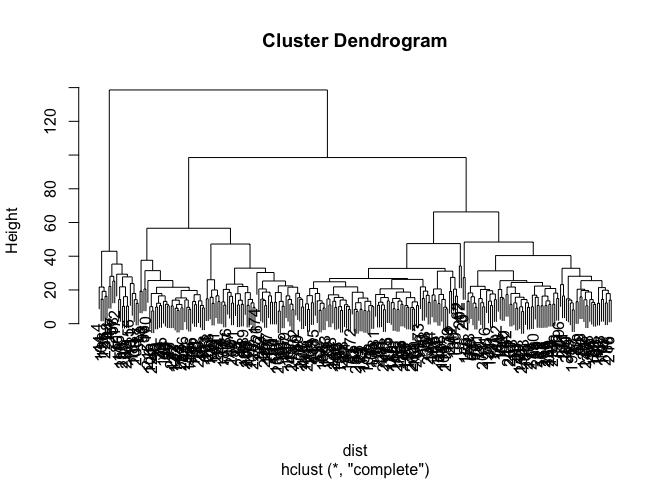

```r
clus = hclust(dist,method = "complete")
plot(clus)
```

```r
hcut= cutree(clus,k=3)
print('Iran is in cluster:')
```

```
## [1] "Iran is in cluster:"
```

```r
hcut[210]
```

```
## [1] 2
```

۱۱. سه یافته جالب از داده ها استخراج کنید.

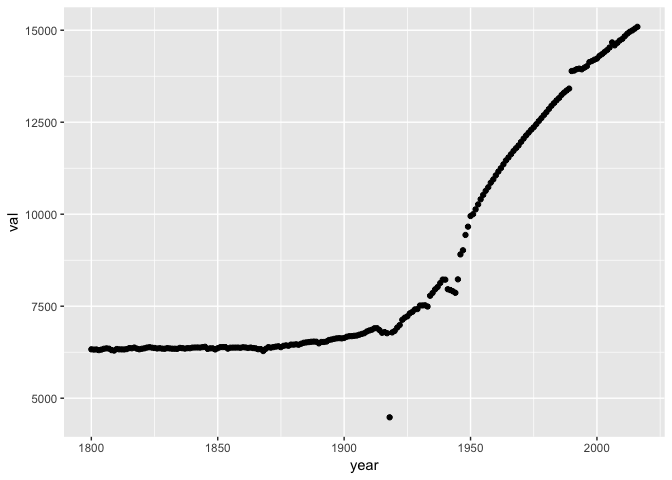

```r
#A:some intresting plots
#life expectancy in iran vs rest of the worls
x=(indicator_life_expectancy_at_birth[,c(2:218)])
mean_life= colSums(x,na.rm = TRUE)
data=data.frame(year=c(1800:2016),val=c(1800:2016))
data$val=mean_life
iran_data=indicator_life_expectancy_at_birth[c(2:218),] %>% filter(`Life expectancy`=='Iran')

iran_data=iran_data %>% gather('year','val',2:218)
ggplot()+geom_point(data=data,aes(x=year,y=val))
```

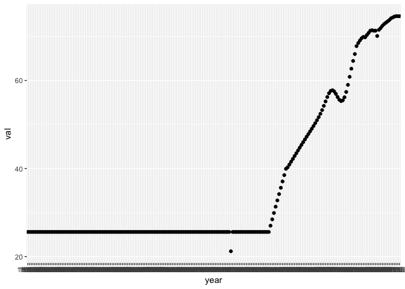

```r
ggplot()+geom_point(data=iran_data,aes(x=year,y=val))
```

```r
#میبینیم که شیب رشد امید به زندگی نسبت به متوسط جهان بیشتر است

#B
#ارتباط سطح تحصیلات و سن ازدواج
library(readxl)
indicator_age_of_marriage <- read_excel("/Users/macbook/Downloads/indicator age of marriage.xlsx")
age=indicator_age_of_marriage[,c(1,117)]
lit<- read_excel("/Users/macbook/Downloads/indicator SE_ADT_LITR_ZS.xls.xlsx")
lit=lit[,c(1,38)]
lit=lit %>% filter(lit$`Adult (15+) literacy rate (%). Total` %in% age$X__1)
age=age %>% filter(age$X__1 %in% lit$`Adult (15+) literacy rate (%). Total`)
cor.test(age$`2005.0`,lit$`2011.0`)
```

```
##
##  Pearson's product-moment correlation
##
## data:  age$`2005.0` and lit$`2011.0`
## t = 1.0775, df = 69, p-value = 0.285
## alternative hypothesis: true correlation is not equal to 0
## 95 percent confidence interval:
##  -0.1079057  0.3513944
## sample estimates:
##       cor
## 0.1286365
```

```r
#نمستوانیم بگوییم سن ازدواج با تحصیلات ارتباطی دارد

#C
indicator_gdp_total_ppp=indicator_gdp_total_ppp %>% filter(indicator_gdp_total_ppp$`Total GDP, PPP` %in%lit$`Adult (15+) literacy rate (%). Total`)

lit=lit %>% filter(lit$`Adult (15+) literacy rate (%). Total` %in% indicator_gdp_total_ppp$`Total GDP, PPP`)
cor.test(lit$`2011.0`,indicator_gdp_total_ppp$`2011.0`)
```

```
##
##  Pearson's product-moment correlation
##
## data:  lit$`2011.0` and indicator_gdp_total_ppp$`2011.0`
## t = 0.27801, df = 72, p-value = 0.7818
## alternative hypothesis: true correlation is not equal to 0
## 95 percent confidence interval:
##  -0.1972285  0.2593045
## sample estimates:
##        cor
## 0.03274603
```

```r
#نمیتوانیم بگوییم کشور هایی با تحصیلات بالاتر سطح اقتصادی بهتری دارند
```